# Chapter 3: ARIMA Models

## 1. Autoregressive Moving Average Models

- AR, MA and ARMA models
- Backshift operator, mean square convergence
- Causal and explosive, stochastically equivalent
- Nonuniqueness and invertibility
- Matching, Taylor expansion for functions of complex variables
- Causal and invertible conditions for ARMA, parameter redundancy

## 2. Difference Equations

- General homogeneous difference Equations
- General solution
- ACF of AR(2), $\psi$ weights for ARMA

## 3. Autocorrelation and Partial Autocorrelation

- Definition and motivation
- Basics of regression
- Partial correlation and conditional correlation
- ACF and PACF for AR and MA
- Interpret the ACF and PACF plots

## 4. Forecasting

- Mean square loss function and conditional mean
- Linear predictor and best linear predictor
- Prediction equations: derivation and matrix form, mean square prediction error
- The Durbin-Levinson algorithm: induction proof and projection proof
- The innovation algorithm: idea and comparison with the Durbin-Levinson
- Forecasting ARMA: forecasts based on finite and infinite past, truncated prediction

## 5. Estimation

- Method of moments: Yule-Walker equations, the Durbin-Levinson algorithm
- MLE and least square estimation: unconditional and conditional versions
- Large sample properties

## 6. Integrated Models for Nonstationary Data

- Trend model: deterministic and stochastic trends
- ARIMA models
- Forecasting

## Code

### Example 3.2 AR(p)

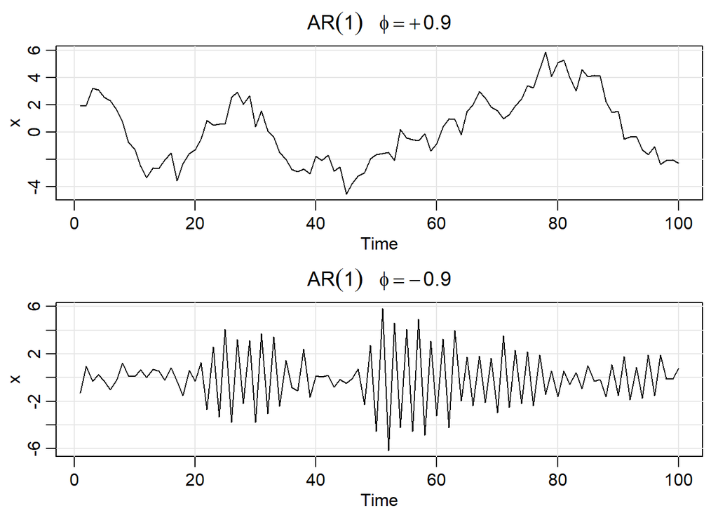

```r
par(mfrow=c(2,1))
# in the expressions below, ~ is a space and == is equal
tsplot(arima.sim(list(order=c(1,0,0), ar=.9), n=100), ylab="x", main=(expression(AR(1)~~~phi==+.9)))
tsplot(arima.sim(list(order=c(1,0,0), ar=-.9), n=100), ylab="x", main=(expression(AR(1)~~~phi==-.9)))
```

### Example 3.5 MA(1)

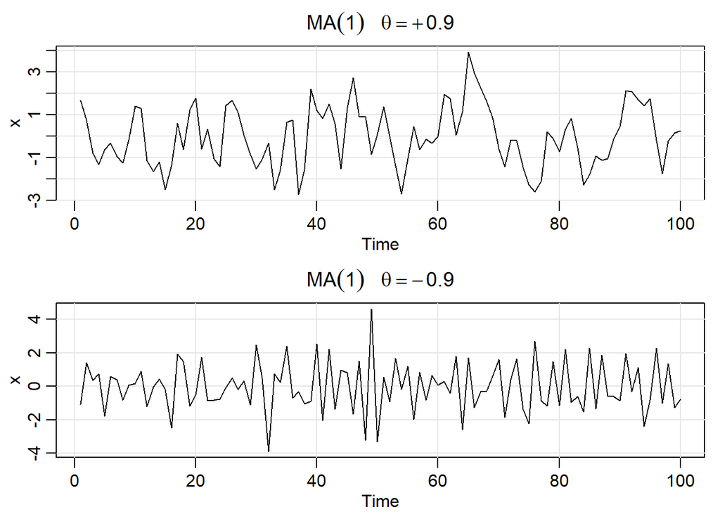

```r
par(mfrow=c(2,1))
tsplot(arima.sim(list(order=c(0,0,1), ma=.9), n=100), ylab="x", main=(expression(MA(1)~~~theta==+.9)))
tsplot(arima.sim(list(order=c(0,0,1), ma=-.9), n=100), ylab="x", main=(expression(MA(1)~~~theta==-.9)))
```

### Example 3.11 AR(2) with complex roots

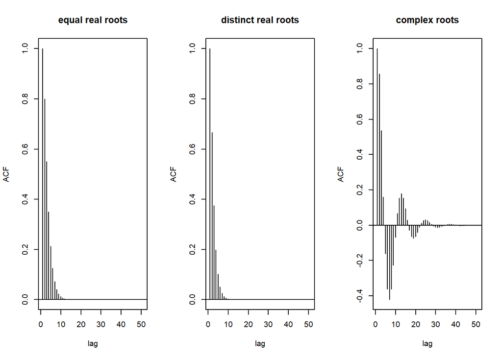

```r
par(mfrow=c(1,3))
ACF = ARMAacf(ar=c(1,-.25), ma=0, 50)
plot(ACF, type="h", xlab="lag", main="equal real roots")
abline(h=0)

ACF = ARMAacf(ar=c(.75,-.125), ma=0, 50)
plot(ACF, type="h", xlab="lag", main="distinct real roots")
abline(h=0)

ACF = ARMAacf(ar=c(1.5,-.75), ma=0, 50)
plot(ACF, type="h", xlab="lag", main="complex roots")
abline(h=0)
```

### Example 3.16 ACF and PACF of AR(p)

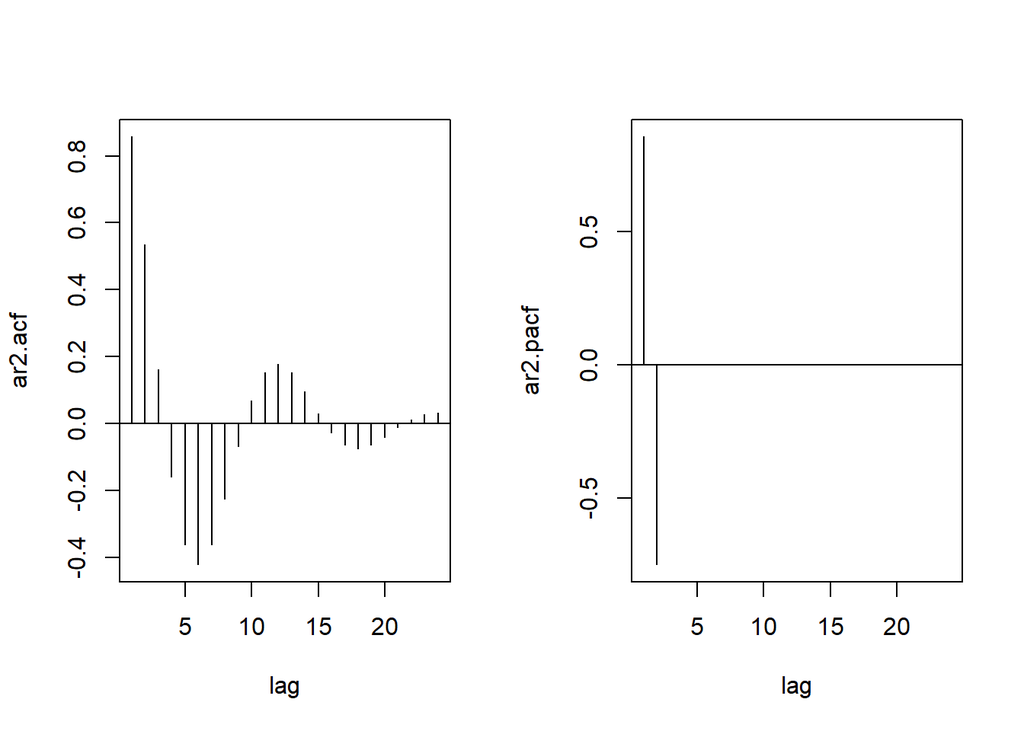

```r
ar2.acf = ARMAacf(ar=c(1.5,-.75), ma=0, 24)[-1]
ar2.pacf = ARMAacf(ar=c(1.5,-.75), ma=0, 24, pacf=TRUE)
par(mfrow=c(1,2))
plot(ar2.acf, type="h", xlab="lag")
abline(h=0)
plot(ar2.pacf, type="h", xlab="lag")
abline(h=0)
```

### Example 3.18 Preliminary analysis of Rec

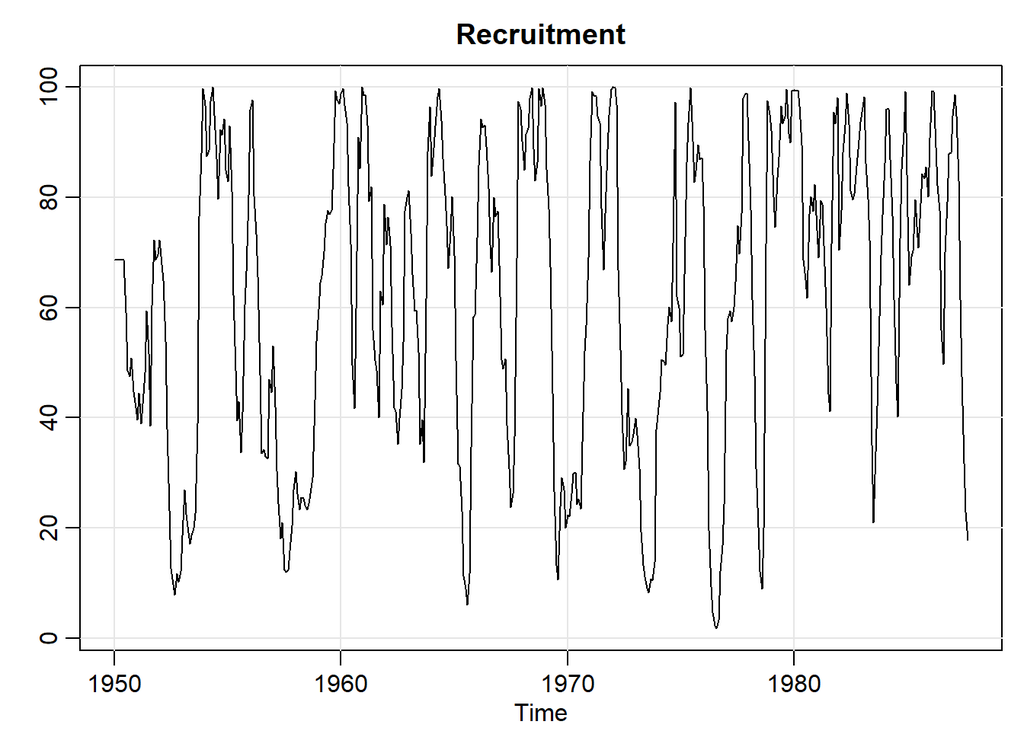

```r
tsplot(rec, ylab="", main="Recruitment")
```

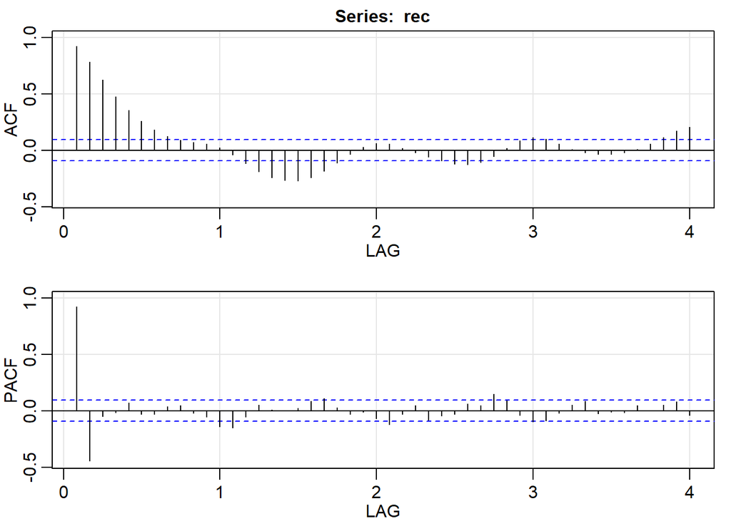

```
##         ACF  PACF
##  [1,]  0.92  0.92
##  [2,]  0.78 -0.44
##  [3,]  0.63 -0.05
##  [4,]  0.48 -0.02
##  [5,]  0.36  0.07
##  [6,]  0.26 -0.03
##  [7,]  0.18 -0.03
##  [8,]  0.13  0.04
##  [9,]  0.09  0.05
## [10,]  0.07 -0.02
## [11,]  0.06 -0.05
## [12,]  0.02 -0.14
## [13,] -0.04 -0.15
## [14,] -0.12 -0.05
```

[output cut: 34 more lines]

```r
acf2(rec, 48)     # will produce values and a graphic
```

```r
(regr = ar.ols(rec, order=2, demean=F, intercept=TRUE))  # regression
```

```
##
## Call:
## ar.ols(x = rec, order.max = 2, demean = F, intercept = TRUE)
##
## Coefficients:
##       1        2
##  1.3541  -0.4632
##
## Intercept: 6.737 (1.111)
##
## Order selected 2  sigma^2 estimated as  89.72
```

```r
regr$asy.se.coef  # standard errors
```

```
## $x.mean
## [1] 1.110599
##
## $ar
## [1] 0.04178901 0.04187942
```

### Example 3.25 Forecasting the Recruitment Series

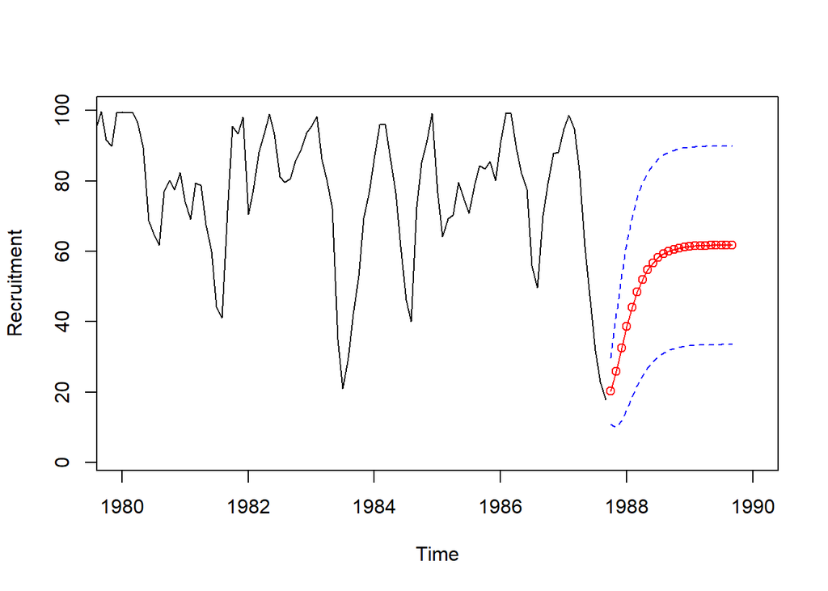

```r
regr = ar.ols(rec, order=2, demean=FALSE, intercept=TRUE)
fore = predict(regr, n.ahead=24)
ts.plot(rec, fore$pred, col=1:2, xlim=c(1980,1990), ylab="Recruitment")
lines(fore$pred, type="p", col=2)
lines(fore$pred+fore$se, lty="dashed", col=4)
lines(fore$pred-fore$se, lty="dashed", col=4)
```

### Example 3.28 Yule-Walker Estimation of the Recruitment Series

```r
rec.yw = ar.yw(rec, order=2)
rec.yw$x.mean  # = 62.26278 (mean estimate)
```

```
## [1] 62.26278
```

```r
rec.yw$ar      # = 1.3315874, -.4445447  (parameter estimates)
```

```
## [1]  1.3315874 -0.4445447
```

```r
sqrt(diag(rec.yw$asy.var.coef))  # = .04222637, .04222637  (standard errors)
```

```
## [1] 0.04222637 0.04222637
```

```r
rec.yw$var.pred  # = 94.79912 (error variance estimate)
```

```
## [1] 94.79912
```

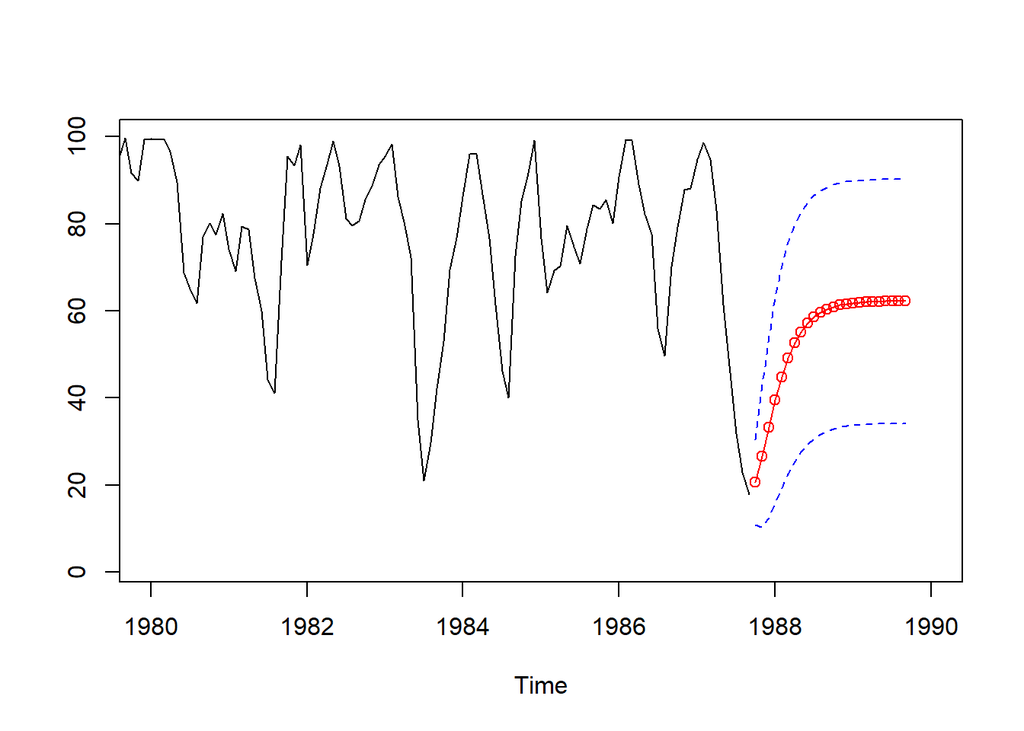

```r
rec.pr = predict(rec.yw, n.ahead=24)
U = rec.pr$pred + rec.pr$se
L = rec.pr$pred - rec.pr$se
minx = min(rec,L); maxx = max(rec,U)
ts.plot(rec, rec.pr$pred, xlim=c(1980,1990), ylim=c(minx,maxx))
lines(rec.pr$pred, col="red", type="o")
lines(U, col="blue", lty="dashed")
lines(L, col="blue", lty="dashed")
```

### Example 3.31 MLE for the Recruitment Series

```r
rec.mle = ar.mle(rec, order=2)
rec.mle$x.mean
```

```
## [1] 62.26153
```

```r
rec.mle$ar
```

```
## [1]  1.3512809 -0.4612736
```

```r
sqrt(diag(rec.mle$asy.var.coef))
```

```
## [1] 0.04099159 0.04099159
```

```r
rec.mle$var.pred
```

```
## [1] 89.33597
```

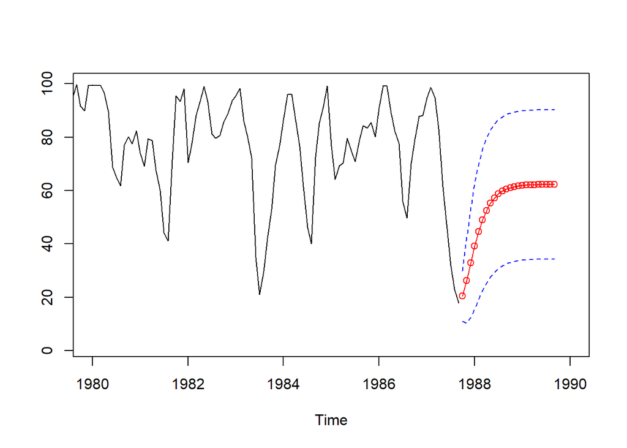

```r
rec.pr = predict(rec.mle, n.ahead=24)
U = rec.pr$pred + rec.pr$se
L = rec.pr$pred - rec.pr$se
minx = min(rec,L); maxx = max(rec,U)
ts.plot(rec, rec.pr$pred, xlim=c(1980,1990), ylim=c(minx,maxx))
lines(rec.pr$pred, col="red", type="o")
lines(U, col="blue", lty="dashed")
lines(L, col="blue", lty="dashed")
```

### Example 3.33 Fitting the Glacial Varve Series

```r
x = diff(log(varve))
# Evaluate Sc on a Grid
c(0) -> w -> z
c() -> Sc -> Sz -> Szw
num = length(x)
th = seq(-.3,-.94,-.01)
for (p in 1:length(th)){
  for (i in 2:num){ w[i] = x[i]-th[p]*w[i-1] }
  Sc[p] = sum(w^2) }
plot(th, Sc, type="l", ylab=expression(S[c](theta)), xlab=expression(theta),
     lwd=2)
# Gauss-Newton Estimation
r = acf(x, lag=1, plot=FALSE)$acf[-1]
rstart = (1-sqrt(1-4*(r^2)))/(2*r) # from (3.105)
c(0) -> w -> z
c() -> Sc -> Sz -> Szw -> para
niter = 12
para[1] = rstart
for (p in 1:niter){
  for (i in 2:num){ w[i] = x[i]-para[p]*w[i-1]
  z[i] = w[i-1]-para[p]*z[i-1] }
  Sc[p] = sum(w^2)
  Sz[p] = sum(z^2)
  Szw[p] = sum(z*w)
  para[p+1] = para[p] + Szw[p]/Sz[p] }

round(cbind(iteration=0:(niter-1), thetahat=para[1:niter] , Sc , Sz ), 3)
```

```
##       iteration thetahat      Sc      Sz
##  [1,]         0   -0.495 158.739 171.240
##  [2,]         1   -0.668 150.747 235.266
##  [3,]         2   -0.733 149.264 300.562
##  [4,]         3   -0.756 149.031 336.823
##  [5,]         4   -0.766 148.990 354.173
##  [6,]         5   -0.769 148.982 362.167
##  [7,]         6   -0.771 148.980 365.801
##  [8,]         7   -0.772 148.980 367.446
##  [9,]         8   -0.772 148.980 368.188
## [10,]         9   -0.772 148.980 368.522
## [11,]        10   -0.773 148.980 368.673
## [12,]        11   -0.773 148.980 368.741
```

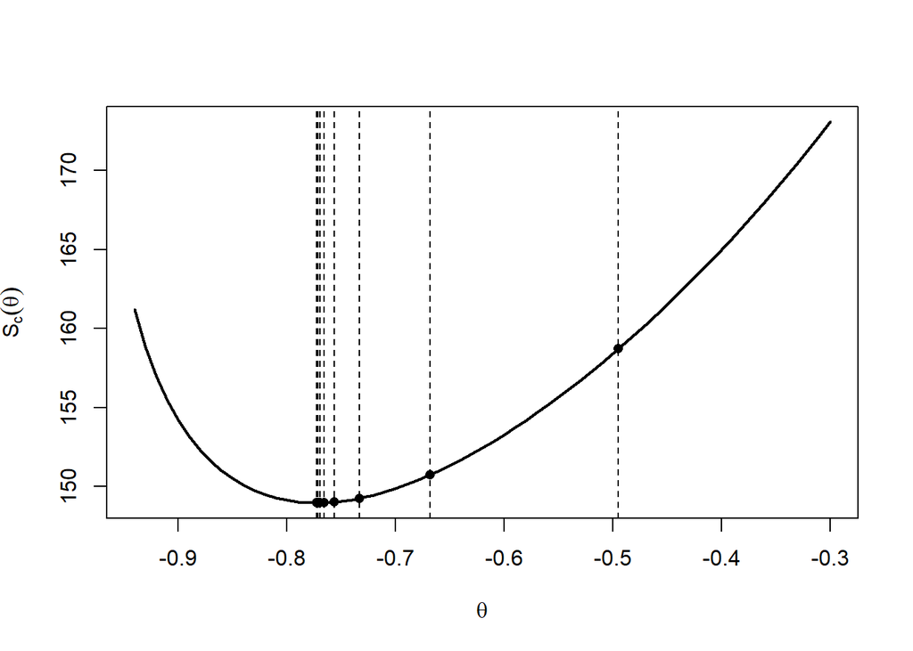

```r
abline(v = para[1:12], lty=2)
points(para[1:12], Sc[1:12], pch=16)
```

### Example 3.38 IMA(1,1) and EWMA

```r
set.seed(666)
x = arima.sim(list(order = c(0,1,1), ma = -0.8), n = 100)
(x.ima = HoltWinters(x, beta=FALSE, gamma=FALSE))  # Î± is 1-Î» here
```

```
## Holt-Winters exponential smoothing without trend and without seasonal component.
##
## Call:
## HoltWinters(x = x, beta = FALSE, gamma = FALSE)
##
## Smoothing parameters:
##  alpha: 0.1663072
##  beta : FALSE
##  gamma: FALSE
##
## Coefficients:
##        [,1]
## a -2.241533
```

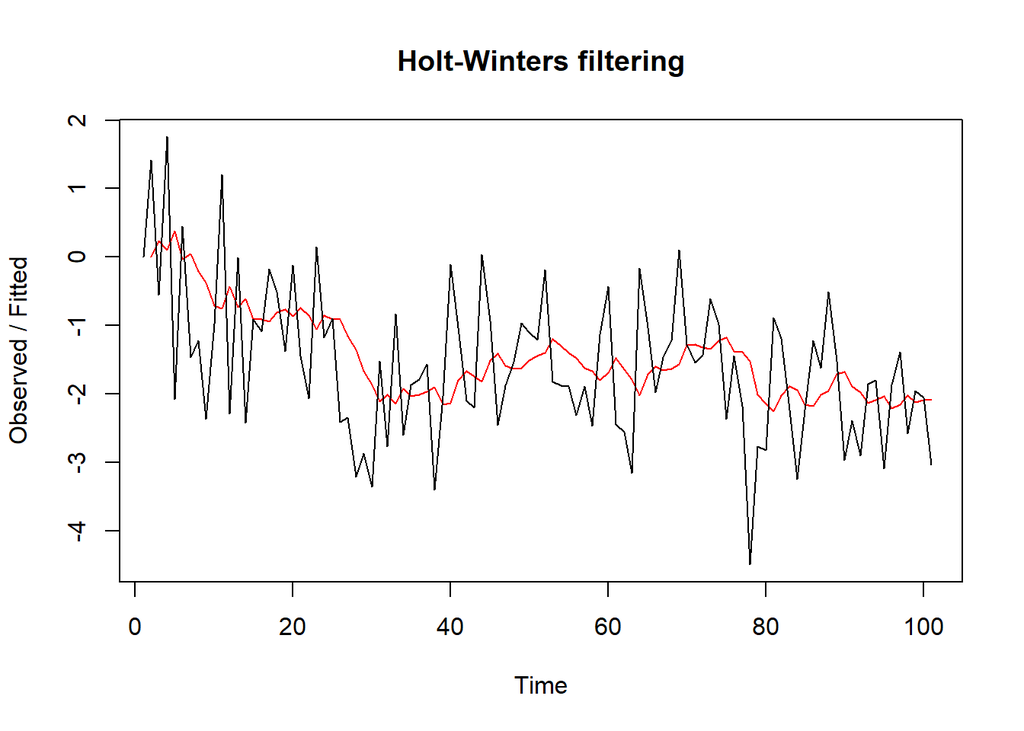

```r
plot(x.ima)
```